Belton Armando Jeremias Manhica belton.xd3@gmail.com

# ExtraaLearn Project

## Context

The EdTech industry has been surging in the past decade immensely, and according to a forecast, the Online Education market would be worth $286.62bn by 2023 with a compound annual growth rate (CAGR) of 10.26% from 2018 to 2023. The modern era of online education has enforced a lot in its growth and expansion beyond any limit. Due to having many dominant features like ease of information sharing, personalized learning experience, transparency of assessment, etc, it is now preferable to traditional education.

In the present scenario due to the Covid-19, the online education sector has witnessed rapid growth and is attracting a lot of new customers. Due to this rapid growth, many new companies have emerged in this industry. With the availability and ease of use of digital marketing resources, companies can reach out to a wider audience with their offerings. The customers who show interest in these offerings are termed as leads. There are various sources of obtaining leads for Edtech companies, like

- The customer interacts with the marketing front on social media or other online platforms.
- The customer browses the website/app and downloads the brochure
- The customer connects through emails for more information.

The company then nurtures these leads and tries to convert them to paid customers. For this, the representative from the organization connects with the lead on call or through email to share further details.

## Objective

ExtraaLearn is an initial stage startup that offers programs on cutting-edge technologies to students and professionals to help them upskill/reskill. With a large number of leads being generated on a regular basis, one of the issues faced by ExtraaLearn is to identify which of the leads are more likely to convert so that they can allocate resources accordingly. You, as a data scientist at ExtraaLearn, have been provided the leads data to:

- Analyze and build an ML model to help identify which leads are more likely to convert to paid customers,
- Find the factors driving the lead conversion process
- Create a profile of the leads which are likely to convert

## Data Description

The data contains the different attributes of leads and their interaction details with ExtraaLearn. The detailed data dictionary is given below.

**Data Dictionary**

- ID: ID of the lead
- age: Age of the lead
- current_occupation: Current occupation of the lead. Values include 'Professional','Unemployed',and 'Student'
- first_interaction: How did the lead first interacted with ExtraaLearn. Values include 'Website', 'Mobile App'
- profile_completed: What percentage of profile has been filled by the lead on the website/mobile app. Values include Low - (0-50%), Medium - (50-75%), High (75-100%)
- website_visits: How many times has a lead visited the website
- time_spent_on_website: Total time spent on the website
- page_views_per_visit: Average number of pages on the website viewed during the visits.
- last_activity: Last interaction between the lead and ExtraaLearn.
  - Email Activity: Seeking for details about program through email, Representative shared information with lead like brochure of program , etc
  - Phone Activity: Had a Phone Conversation with representative, Had conversation over SMS with representative, etc
  - Website Activity: Interacted on live chat with representative, Updated profile on website, etc
- print_media_type1: Flag indicating whether the lead had seen the ad of ExtraaLearn in the Newspaper.
- print_media_type2: Flag indicating whether the lead had seen the ad of ExtraaLearn in the Magazine.
- digital_media: Flag indicating whether the lead had seen the ad of ExtraaLearn on the digital platforms.
- educational_channels: Flag indicating whether the lead had heard about ExtraaLearn in the education channels like online forums, discussion threads, educational websites, etc.
- referral: Flag indicating whether the lead had heard about ExtraaLearn through reference.
- status: Flag indicating whether the lead was converted to a paid customer or not.

## Importing necessary libraries and data

```python
#import libraries for data manipulation
import numpy as np
import pandas as pd

#import liabries for data visualization
import seaborn as sns
import matplotlib.pyplot as plt

#remove the limit for the number of rows to display
pd.options.display.max_columns = None

#set a limit for the number of rows to display to 1000
pd.options.display.max_rows = 1000

# import data split library
from sklearn.model_selection import train_test_split

#data transformation, encoding, and scaling libraries
from sklearn.preprocessing import LabelEncoder, OneHotEncoder, TargetEncoder
from sklearn.preprocessing import RobustScaler, StandardScaler, QuantileTransformer


#import classifiers
from sklearn.linear_model import LogisticRegression, Lasso, Ridge
from sklearn.tree import DecisionTreeClassifier
from sklearn.ensemble import RandomForestClassifier

#import hyperparameter tuning libraries
from sklearn.model_selection import GridSearchCV, RandomizedSearchCV

#Import metric library
from sklearn.metrics import classification_report,confusion_matrix,roc_auc_score

#ignore warnings
import warnings
warnings.filterwarnings('ignore')

#other libraries
from sklearn.tree import plot_tree
from sklearn.metrics import precision_recall_curve
```

```python
#mount my google drive file
from google.colab import drive
drive.mount('/content/drive')
```

```python
# import dataset
data = pd.read_csv('/content/drive/MyDrive/Great Learning/ExtraaLearn.csv')
```

## Data Overview

- Observations
- Sanity checks

```python
#data disciption
data.info()
```

```
<class 'pandas.core.frame.DataFrame'>
RangeIndex: 4612 entries, 0 to 4611
Data columns (total 15 columns):
 #   Column                 Non-Null Count  Dtype
---  ------                 --------------  -----
 0   ID                     4612 non-null   object
 1   age                    4612 non-null   int64
 2   current_occupation     4612 non-null   object
 3   first_interaction      4612 non-null   object
 4   profile_completed      4612 non-null   object
 5   website_visits         4612 non-null   int64
 6   time_spent_on_website  4612 non-null   int64
 7   page_views_per_visit   4612 non-null   float64
 8   last_activity          4612 non-null   object
 9   print_media_type1      4612 non-null   object
 10  print_media_type2      4612 non-null   object
 11  digital_media          4612 non-null   object
 12  educational_channels   4612 non-null   object
 13  referral               4612 non-null   object
 14  status                 4612 non-null   int64
dtypes: float64(1), int64(4), object(10)
memory usage: 540.6+ KB
```

```python
#Check the content of the data
data.head(10).T
```

|  | 0 | 1 | 2 | 3 | 4 | 5 | 6 | 7 | 8 | 9 |
| --- | --- | --- | --- | --- | --- | --- | --- | --- | --- | --- |
| ID | EXT001 | EXT002 | EXT003 | EXT004 | EXT005 | EXT006 | EXT007 | EXT008 | EXT009 | EXT010 |
| age | 57 | 56 | 52 | 53 | 23 | 50 | 56 | 57 | 57 | 59 |
| current_occupation | Unemployed | Professional | Professional | Unemployed | Student | Unemployed | Professional | Professional | Professional | Professional |
| first_interaction | Website | Mobile App | Website | Website | Website | Mobile App | Mobile App | Mobile App | Mobile App | Mobile App |
| profile_completed | High | Medium | Medium | High | High | High | Medium | Medium | High | High |
| website_visits | 7 | 2 | 3 | 4 | 4 | 4 | 13 | 2 | 2 | 1 |
| time_spent_on_website | 1639 | 83 | 330 | 464 | 600 | 212 | 625 | 517 | 2231 | 1819 |
| page_views_per_visit | 1.861 | 0.32 | 0.074 | 2.057 | 16.914 | 5.682 | 2.015 | 2.985 | 2.194 | 3.513 |
| last_activity | Website Activity | Website Activity | Website Activity | Website Activity | Email Activity | Phone Activity | Website Activity | Email Activity | Phone Activity | Phone Activity |
| print_media_type1 | Yes | No | No | No | No | No | No | No | No | No |
| print_media_type2 | No | No | No | No | No | No | No | No | No | No |
| digital_media | Yes | No | Yes | No | No | No | Yes | No | Yes | No |
| educational_channels | No | Yes | No | No | No | Yes | No | No | No | No |
| referral | No | No | No | No | No | No | No | No | No | No |
| status | 1 | 0 | 0 | 1 | 0 | 0 | 1 | 0 | 1 | 0 |

Comments:

- There are 10 object values
- 5 numerical values
- There are no empty/null values in our data
- There is a total of 15 columns and 4612 rows/ observations

```python
#descriptive statistics for numerical data
data.describe().round(2).T
```

|  | count | mean | std | min | 25% | 50% | 75% | max |
| --- | --- | --- | --- | --- | --- | --- | --- | --- |
| age | 4612.0 | 46.20 | 13.16 | 18.0 | 36.00 | 51.00 | 57.00 | 63.00 |
| website_visits | 4612.0 | 3.57 | 2.83 | 0.0 | 2.00 | 3.00 | 5.00 | 30.00 |
| time_spent_on_website | 4612.0 | 724.01 | 743.83 | 0.0 | 148.75 | 376.00 | 1336.75 | 2537.00 |
| page_views_per_visit | 4612.0 | 3.03 | 1.97 | 0.0 | 2.08 | 2.79 | 3.76 | 18.43 |
| status | 4612.0 | 0.30 | 0.46 | 0.0 | 0.00 | 0.00 | 1.00 | 1.00 |

```python
#descriptive statistics for categorical data
data.describe(include = 'object').T
```

|  | count | unique | top | freq |
| --- | --- | --- | --- | --- |
| ID | 4612 | 4612 | EXT4612 | 1 |
| current_occupation | 4612 | 3 | Professional | 2616 |
| first_interaction | 4612 | 2 | Website | 2542 |
| profile_completed | 4612 | 3 | High | 2264 |
| last_activity | 4612 | 3 | Email Activity | 2278 |
| print_media_type1 | 4612 | 2 | No | 4115 |
| print_media_type2 | 4612 | 2 | No | 4379 |
| digital_media | 4612 | 2 | No | 4085 |
| educational_channels | 4612 | 2 | No | 3907 |
| referral | 4612 | 2 | No | 4519 |

Comments:

```python
#check for duplicates
data.duplicated().sum()
```

```
np.int64(0)
```

```python
#check for garbage values
data.select_dtypes(include ='object').apply(lambda x: x=='..').sum()
```

|  | 0 |
| --- | --- |
| ID | 0 |
| current_occupation | 0 |
| first_interaction | 0 |
| profile_completed | 0 |
| last_activity | 0 |
| print_media_type1 | 0 |
| print_media_type2 | 0 |
| digital_media | 0 |
| educational_channels | 0 |
| referral | 0 |

**dtype:** int64

## Exploratory Data Analysis (EDA)

- EDA is an important part of any project involving data.
- It is important to investigate and understand the data better before building a model with it.
- A few questions have been mentioned below which will help you approach the analysis in the right manner and generate insights from the data.
- A thorough analysis of the data, in addition to the questions mentioned below, should be done.

**Questions**

1. Leads will have different expectations from the outcome of the course and the current occupation may play a key role in getting them to participate in the program. Find out how current occupation affects lead status.
2. The company's first impression on the customer must have an impact. Do the first channels of interaction have an impact on the lead status?
3. The company uses multiple modes to interact with prospects. Which way of interaction works best?
4. The company gets leads from various channels such as print media, digital media, referrals, etc. Which of these channels have the highest lead conversion rate?
5. People browsing the website or mobile application are generally required to create a profile by sharing their personal data before they can access additional information.Does having more details about a prospect increase the chances of conversion?

```
Skew: -0.72
```

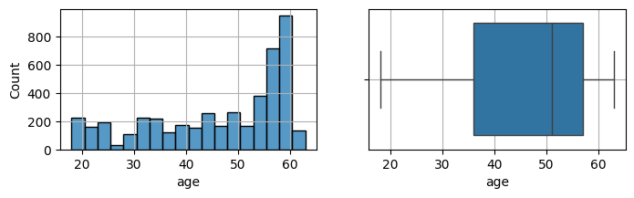

```
Skew: 2.16
```

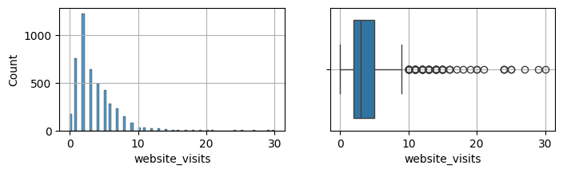

```
Skew: 0.95
```

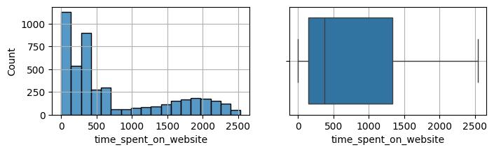

```
Skew: 1.27
```

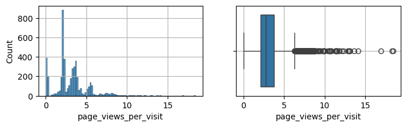

```
Skew: 0.88
```

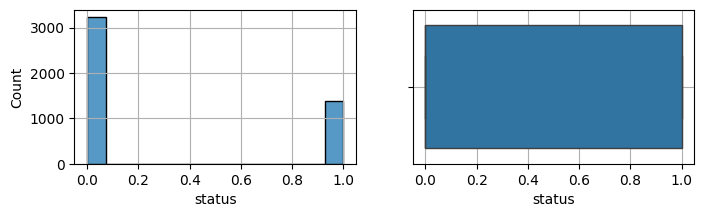

```python
#Histogram and bloxplots

for i in data.select_dtypes(include = 'number').columns: # select all columns with numeric values
  print('\n') # line break
  print('Skew:', round(data[i].skew(),2))
  plt.figure(figsize = (8,2))
  plt.subplot(1,2,1)
  sns.histplot(data, x =i)
  plt.grid(visible = None)
  plt.subplot(1,2,2)
  sns.boxplot(data, x=i)
  plt.grid(visible = None)
  plt.show()
```

- Age has no outliers but is not normally distributed and is left skewed.
- Website visits has many outliears. These outliers appear to me realistic and not an data entry error. Since there are customers who visit the website multiple times. The same goes for page views per visit.

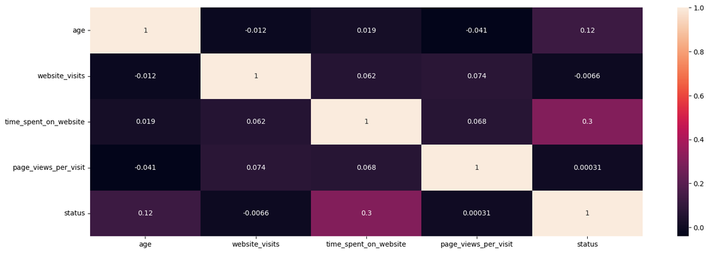

```python
#correlation matrix

plt.figure(figsize= (18, 6))
sns.heatmap(data.corr(numeric_only= True), annot = True)
```

The correlation amongst our variables is very weak. However, time spent on website seems to correlate with status more strongly than the rest of the variables.

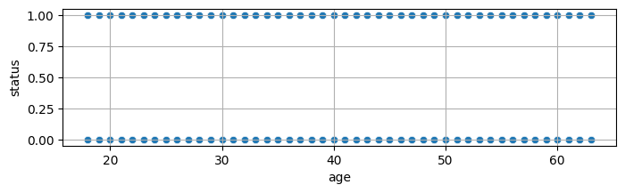

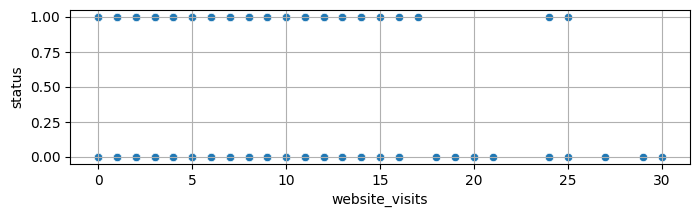

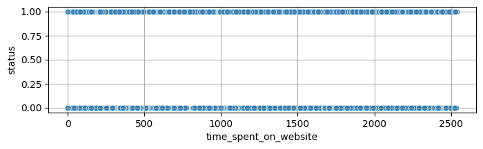

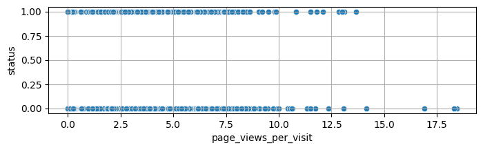

```python
#check the relashionship between status and other variables

for col in data.select_dtypes(include = 'number').columns.tolist():
  if col != 'status':
      print('\n') #line break
      plt.figure(figsize =(8,2))
      sns.scatterplot(data, x = col , y = 'status')
      plt.grid(visible = None)
      plt.show()
```

## Data Preprocessing

- Missing value treatment (if needed)
- Feature engineering (if needed)
- Outlier detection and treatment (if needed)
- Preparing data for modeling
- Any other preprocessing steps (if needed)

```python
#drop ID since it is irrelevant in our analysis
data.drop('ID', axis = 1, inplace = True)
```

```python
data.head()
```

|  | age | current_occupation | first_interaction | profile_completed | website_visits | time_spent_on_website | page_views_per_visit | last_activity | print_media_type1 | print_media_type2 | digital_media | educational_channels | referral | status |
| --- | --- | --- | --- | --- | --- | --- | --- | --- | --- | --- | --- | --- | --- | --- |
| 0 | 57 | Unemployed | Website | High | 7 | 1639 | 1.861 | Website Activity | Yes | No | Yes | No | No | 1 |
| 1 | 56 | Professional | Mobile App | Medium | 2 | 83 | 0.320 | Website Activity | No | No | No | Yes | No | 0 |
| 2 | 52 | Professional | Website | Medium | 3 | 330 | 0.074 | Website Activity | No | No | Yes | No | No | 0 |
| 3 | 53 | Unemployed | Website | High | 4 | 464 | 2.057 | Website Activity | No | No | No | No | No | 1 |
| 4 | 23 | Student | Website | High | 4 | 600 | 16.914 | Email Activity | No | No | No | No | No | 0 |

To have a better idea of the correlation between the variables in our dataset, we are going to convert all categorical variables in to numerical ones. Afterwards, We are going to create new features for the transformed data.

We are going to convert all the binary categorical data with yes and no's into 1 for yes and 0 for no first, and then we will apply one hot encoding to other categorical data.

```python
data_num = data.copy()
```

```python
#convert categorical variables into numerical ones
categ_binary_col = ['print_media_type1',
 'print_media_type2',
 'digital_media',
 'educational_channels',
 'referral']

for i in categ_binary_col:
  data_num[f'f_{i}'] = data_num[i].replace({'No': 0, 'Yes': 1})
```

```python
data_num.head()
```

|  | age | current_occupation | first_interaction | profile_completed | website_visits | time_spent_on_website | page_views_per_visit | last_activity | print_media_type1 | print_media_type2 | digital_media | educational_channels | referral | status | f_print_media_type1 | f_print_media_type2 | f_digital_media | f_educational_channels | f_referral |
| --- | --- | --- | --- | --- | --- | --- | --- | --- | --- | --- | --- | --- | --- | --- | --- | --- | --- | --- | --- |
| 0 | 57 | Unemployed | Website | High | 7 | 1639 | 1.861 | Website Activity | Yes | No | Yes | No | No | 1 | 1 | 0 | 1 | 0 | 0 |
| 1 | 56 | Professional | Mobile App | Medium | 2 | 83 | 0.320 | Website Activity | No | No | No | Yes | No | 0 | 0 | 0 | 0 | 1 | 0 |
| 2 | 52 | Professional | Website | Medium | 3 | 330 | 0.074 | Website Activity | No | No | Yes | No | No | 0 | 0 | 0 | 1 | 0 | 0 |
| 3 | 53 | Unemployed | Website | High | 4 | 464 | 2.057 | Website Activity | No | No | No | No | No | 1 | 0 | 0 | 0 | 0 | 0 |
| 4 | 23 | Student | Website | High | 4 | 600 | 16.914 | Email Activity | No | No | No | No | No | 0 | 0 | 0 | 0 | 0 | 0 |

```python
#convert the rest of the categotical data in to numeric using OneHot encoding
convert_to_num = ['current_occupation',
 'first_interaction',
 'profile_completed',
 'last_activity']

#intialize the OneHotEncoder
onehot = OneHotEncoder(sparse_output= False)

#enconde each colum through a for loop
for i in convert_to_num:
  #fit and transform the encoder to the data
  encoded = onehot.fit_transform(data_num[[i]])

  #create new columns with the encoded data
  list_names = [f'f_{i}_{cat}' for cat in onehot.categories_[0]]

  #add encoded data to the original dataset
  data_num[list_names] = encoded
```

## EDA

- It is a good idea to explore the data once again after manipulating it.

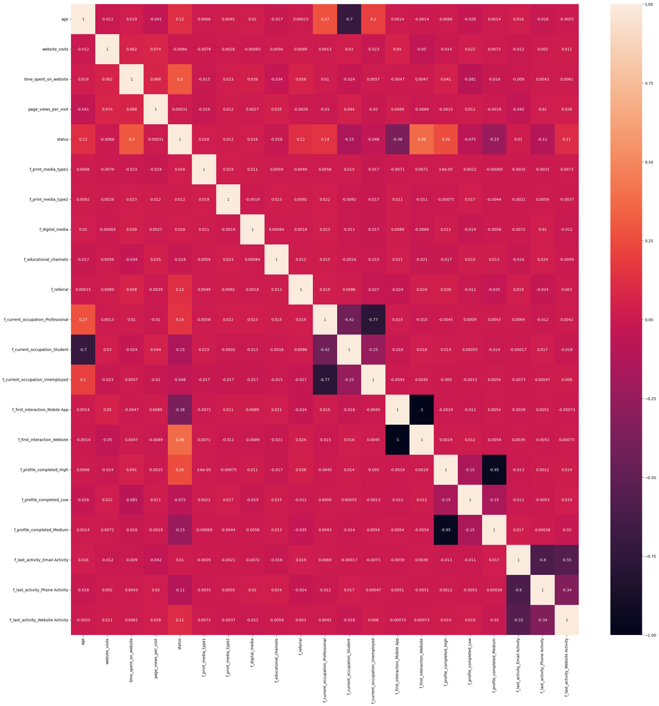

```python
#correlation matrix
plt.figure(figsize= (30, 30))
sns.heatmap(data_num.corr(numeric_only= True), annot = True)
```

Comments:

- Even though the correlations amongst our variables are still on the weak side, now we can see that first interaction through the website correlates with status more than other sources of first interaction. High profile completion also correlects more with status than other than medium and low profile completion. This means that the more information we have about the customer the better.
- First interaction through mobile APP negatively correlates with status
- We also notice that there is a less weak correlation between age and current_occupation_professional. Indicating that the older the lead the higher the chances that they might have a carrear/job.
- Age negatively correlates with current_occupation_student. Indicating that the older the person is, the less likely they will be a student. Age also positively correlates with status. Hence we can thypothesize that most of our paying customers will not be students, but older people who have a carrear/job.
- Leads generated through newspaper, magazines, and digital platforms have a weak positive relationship with status. However, those generated through educational platforms have a weak negative relationship with conversion.

Outlier treatment

```python
scaled_data = data_num.copy()
```

```python
#we are going to deal with outliers for website visits and page views per visit by normalizing the data using a transformer that is robust to outliers
#select columns to normilize
columns_to_normalize = ['age',
 'website_visits',
 'time_spent_on_website',
 'page_views_per_visit']

#set up the transformer
quantile = QuantileTransformer(output_distribution='normal')

#apply the transformer
scaled_data_ = quantile.fit_transform(scaled_data[columns_to_normalize])

#convert normalized data in to a data frame
scaled_data_ = pd.DataFrame(scaled_data_ , columns =columns_to_normalize )
```

```python
scaled_data_
```

|  | age | website_visits | time_spent_on_website | page_views_per_visit |
| --- | --- | --- | --- | --- |
| 0 | 0.593940 | 1.236652 | 0.866833 | -0.960317 |
| 1 | 0.376283 | -0.426601 | -0.862544 | -1.163656 |
| 2 | 0.050204 | 0.094232 | -0.176553 | -1.655287 |
| 3 | 0.095492 | 0.414267 | 0.192557 | -0.734798 |
| 4 | -1.331018 | 0.414267 | 0.346817 | 3.434360 |
| ... | ... | ... | ... | ... |
| 4607 | -0.700711 | 2.611712 | -0.055229 | -0.391137 |
| 4608 | 0.223916 | 1.501861 | 2.057242 | 1.186981 |
| 4609 | 0.868016 | -0.426601 | -0.537980 | -0.020440 |
| 4610 | 0.593940 | -1.176890 | -0.668780 | 0.799151 |
| 4611 | 0.223916 | 0.414267 | 1.921283 | -0.681594 |

4612 rows × 4 columns

```
Skew: -0.72
```

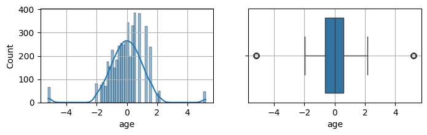

```
Skew: 2.16
```

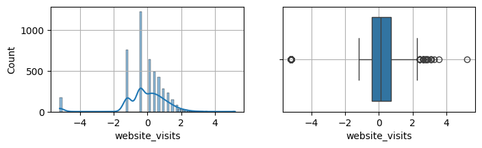

```
Skew: 0.95
```

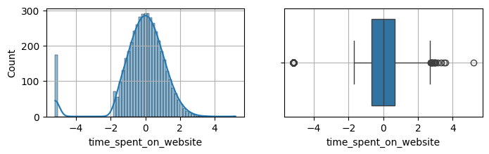

```
Skew: 1.27
```

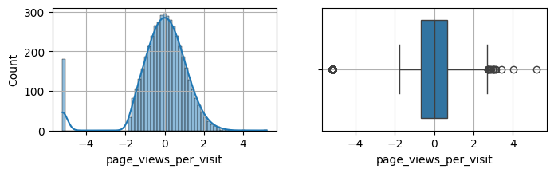

```python
for i in columns_to_normalize:
  print('\n') # line break
  print('Skew:', round(data[i].skew(),2))
  plt.figure(figsize = (8,2))
  plt.subplot(1,2,1)
  sns.histplot(scaled_data_, x =i, kde = True)
  plt.grid(visible = None)
  plt.subplot(1,2,2)
  sns.boxplot(scaled_data_, x=i)
  plt.grid(visible = None)
  plt.show()
```

Now our data is close to a normal/standard distribution.

```python
#add the scaled data into our dataset
scaled_data[columns_to_normalize] = scaled_data_
scaled_data
```

|  | age | current_occupation | first_interaction | profile_completed | website_visits | time_spent_on_website | page_views_per_visit | last_activity | print_media_type1 | print_media_type2 | digital_media | educational_channels | referral | status | f_print_media_type1 | f_print_media_type2 | f_digital_media | f_educational_channels | f_referral | f_current_occupation_Professional | f_current_occupation_Student | f_current_occupation_Unemployed | f_first_interaction_Mobile App | f_first_interaction_Website | f_profile_completed_High | f_profile_completed_Low | f_profile_completed_Medium | f_last_activity_Email Activity | f_last_activity_Phone Activity | … |
| --- | --- | --- | --- | --- | --- | --- | --- | --- | --- | --- | --- | --- | --- | --- | --- | --- | --- | --- | --- | --- | --- | --- | --- | --- | --- | --- | --- | --- | --- | --- |
| 0 | 0.593940 | Unemployed | Website | High | 1.236652 | 0.866833 | -0.960317 | Website Activity | Yes | No | Yes | No | No | 1 | 1 | 0 | 1 | 0 | 0 | 0.0 | 0.0 | 1.0 | 0.0 | 1.0 | 1.0 | 0.0 | 0.0 | 0.0 | 0.0 | … |
| 1 | 0.376283 | Professional | Mobile App | Medium | -0.426601 | -0.862544 | -1.163656 | Website Activity | No | No | No | Yes | No | 0 | 0 | 0 | 0 | 1 | 0 | 1.0 | 0.0 | 0.0 | 1.0 | 0.0 | 0.0 | 0.0 | 1.0 | 0.0 | 0.0 | … |
| 2 | 0.050204 | Professional | Website | Medium | 0.094232 | -0.176553 | -1.655287 | Website Activity | No | No | Yes | No | No | 0 | 0 | 0 | 1 | 0 | 0 | 1.0 | 0.0 | 0.0 | 0.0 | 1.0 | 0.0 | 0.0 | 1.0 | 0.0 | 0.0 | … |
| 3 | 0.095492 | Unemployed | Website | High | 0.414267 | 0.192557 | -0.734798 | Website Activity | No | No | No | No | No | 1 | 0 | 0 | 0 | 0 | 0 | 0.0 | 0.0 | 1.0 | 0.0 | 1.0 | 1.0 | 0.0 | 0.0 | 0.0 | 0.0 | … |
| 4 | -1.331018 | Student | Website | High | 0.414267 | 0.346817 | 3.434360 | Email Activity | No | No | No | No | No | 0 | 0 | 0 | 0 | 0 | 0 | 0.0 | 1.0 | 0.0 | 0.0 | 1.0 | 1.0 | 0.0 | 0.0 | 1.0 | 0.0 | … |
| ... | ... | ... | ... | ... | ... | ... | ... | ... | ... | ... | ... | ... | ... | ... | ... | ... | ... | ... | ... | ... | ... | ... | ... | ... | ... | ... | ... | ... | ... | … |
| 4607 | -0.700711 | Unemployed | Mobile App | Medium | 2.611712 | -0.055229 | -0.391137 | Phone Activity | No | No | No | Yes | No | 0 | 0 | 0 | 0 | 1 | 0 | 0.0 | 0.0 | 1.0 | 1.0 | 0.0 | 0.0 | 0.0 | 1.0 | 0.0 | 1.0 | … |
| 4608 | 0.223916 | Professional | Mobile App | Medium | 1.501861 | 2.057242 | 1.186981 | Email Activity | No | No | No | No | No | 0 | 0 | 0 | 0 | 0 | 0 | 1.0 | 0.0 | 0.0 | 1.0 | 0.0 | 0.0 | 0.0 | 1.0 | 1.0 | 0.0 | … |
| 4609 | 0.868016 | Professional | Website | High | -0.426601 | -0.537980 | -0.020440 | Email Activity | No | No | No | No | No | 1 | 0 | 0 | 0 | 0 | 0 | 1.0 | 0.0 | 0.0 | 0.0 | 1.0 | 1.0 | 0.0 | 0.0 | 1.0 | 0.0 | … |
| 4610 | 0.593940 | Professional | Mobile App | Medium | -1.176890 | -0.668780 | 0.799151 | Website Activity | Yes | No | No | No | No | 0 | 1 | 0 | 0 | 0 | 0 | 1.0 | 0.0 | 0.0 | 1.0 | 0.0 | 0.0 | 0.0 | 1.0 | 0.0 | 0.0 | … |
| 4611 | 0.223916 | Professional | Website | Medium | 0.414267 | 1.921283 | -0.681594 | Phone Activity | No | No | No | No | No | 0 | 0 | 0 | 0 | 0 | 0 | 1.0 | 0.0 | 0.0 | 0.0 | 1.0 | 0.0 | 0.0 | 1.0 | 0.0 | 1.0 | … |

4612 rows × 30 columns

```python
#select numerical variables
columns  = scaled_data.select_dtypes(include = 'number').columns.tolist()
```

```python
#select numerical data for our analysis
selected_data = scaled_data[columns]
selected_data
```

|  | age | website_visits | time_spent_on_website | page_views_per_visit | status | f_print_media_type1 | f_print_media_type2 | f_digital_media | f_educational_channels | f_referral | f_current_occupation_Professional | f_current_occupation_Student | f_current_occupation_Unemployed | f_first_interaction_Mobile App | f_first_interaction_Website | f_profile_completed_High | f_profile_completed_Low | f_profile_completed_Medium | f_last_activity_Email Activity | f_last_activity_Phone Activity | f_last_activity_Website Activity |
| --- | --- | --- | --- | --- | --- | --- | --- | --- | --- | --- | --- | --- | --- | --- | --- | --- | --- | --- | --- | --- | --- |
| 0 | 0.593940 | 1.236652 | 0.866833 | -0.960317 | 1 | 1 | 0 | 1 | 0 | 0 | 0.0 | 0.0 | 1.0 | 0.0 | 1.0 | 1.0 | 0.0 | 0.0 | 0.0 | 0.0 | 1.0 |
| 1 | 0.376283 | -0.426601 | -0.862544 | -1.163656 | 0 | 0 | 0 | 0 | 1 | 0 | 1.0 | 0.0 | 0.0 | 1.0 | 0.0 | 0.0 | 0.0 | 1.0 | 0.0 | 0.0 | 1.0 |
| 2 | 0.050204 | 0.094232 | -0.176553 | -1.655287 | 0 | 0 | 0 | 1 | 0 | 0 | 1.0 | 0.0 | 0.0 | 0.0 | 1.0 | 0.0 | 0.0 | 1.0 | 0.0 | 0.0 | 1.0 |
| 3 | 0.095492 | 0.414267 | 0.192557 | -0.734798 | 1 | 0 | 0 | 0 | 0 | 0 | 0.0 | 0.0 | 1.0 | 0.0 | 1.0 | 1.0 | 0.0 | 0.0 | 0.0 | 0.0 | 1.0 |
| 4 | -1.331018 | 0.414267 | 0.346817 | 3.434360 | 0 | 0 | 0 | 0 | 0 | 0 | 0.0 | 1.0 | 0.0 | 0.0 | 1.0 | 1.0 | 0.0 | 0.0 | 1.0 | 0.0 | 0.0 |
| ... | ... | ... | ... | ... | ... | ... | ... | ... | ... | ... | ... | ... | ... | ... | ... | ... | ... | ... | ... | ... | ... |
| 4607 | -0.700711 | 2.611712 | -0.055229 | -0.391137 | 0 | 0 | 0 | 0 | 1 | 0 | 0.0 | 0.0 | 1.0 | 1.0 | 0.0 | 0.0 | 0.0 | 1.0 | 0.0 | 1.0 | 0.0 |
| 4608 | 0.223916 | 1.501861 | 2.057242 | 1.186981 | 0 | 0 | 0 | 0 | 0 | 0 | 1.0 | 0.0 | 0.0 | 1.0 | 0.0 | 0.0 | 0.0 | 1.0 | 1.0 | 0.0 | 0.0 |
| 4609 | 0.868016 | -0.426601 | -0.537980 | -0.020440 | 1 | 0 | 0 | 0 | 0 | 0 | 1.0 | 0.0 | 0.0 | 0.0 | 1.0 | 1.0 | 0.0 | 0.0 | 1.0 | 0.0 | 0.0 |
| 4610 | 0.593940 | -1.176890 | -0.668780 | 0.799151 | 0 | 1 | 0 | 0 | 0 | 0 | 1.0 | 0.0 | 0.0 | 1.0 | 0.0 | 0.0 | 0.0 | 1.0 | 0.0 | 0.0 | 1.0 |
| 4611 | 0.223916 | 0.414267 | 1.921283 | -0.681594 | 0 | 0 | 0 | 0 | 0 | 0 | 1.0 | 0.0 | 0.0 | 0.0 | 1.0 | 0.0 | 0.0 | 1.0 | 0.0 | 1.0 | 0.0 |

4612 rows × 21 columns

```python
#split the data into trainining and validation/testing
train, test = train_test_split(selected_data, test_size = 0.2, stratify=scaled_data['status'], random_state= 42)

#check the shape of the datasets
train.shape, test.shape
```

```
((3689, 21), (923, 21))
```

```python
#separate the target variable from the features matrix

#select the feartures matrix
X_train = train.drop('status', axis = 1)
X_test = test.drop('status', axis = 1)

#select the target variable
y_train = train['status']
y_test = test['status']

#check the shape of the datasets
X_train.shape , y_train.shape, X_test.shape, y_test.shape
```

```
((3689, 20), (3689,), (923, 20), (923,))
```

```python
#create a function that calculate the scores for the classifiers
def metric_score(y_true, y_pred):
  print(f'{name} data') #print the name of the split to which the score belong
  print(classification_report(y_true, y_pred))

#get the confusion matrix
  cm = confusion_matrix(y_true, y_pred)
  fig, ax = plt.subplots(figsize=(8, 8))
  ax.imshow(cm)
  ax.grid(False)
  ax.xaxis.set(ticks=(0, 1), ticklabels=('Predicted 0s', 'Predicted 1s'))
  ax.yaxis.set(ticks=(0, 1), ticklabels=('Actual 0s', 'Actual 1s'))
  ax.set_ylim(1.5, -0.5)
  for i in range(2):
      for j in range(2):
          ax.text(j, i, cm[i, j], ha='center', va='center', color='red')
  plt.show()

#create a function for ROC_AUC score
def metric_for_status(y_true, y_score):
  score_ROC = round(roc_auc_score(y_true,y_score), 3)

  print(f'{name:10s}: {score_ROC}')
  return score
```

```python
#create a list to store a set of train and test data
get_X_y = [
    ('train', X_train, train),
    ('test', X_test, test)
]
```

## Building a Decision Tree model

```
train data
              precision    recall  f1-score   support

           0       0.89      0.90      0.90      2588
           1       0.76      0.75      0.75      1101

    accuracy                           0.85      3689
   macro avg       0.83      0.82      0.82      3689
weighted avg       0.85      0.85      0.85      3689
```

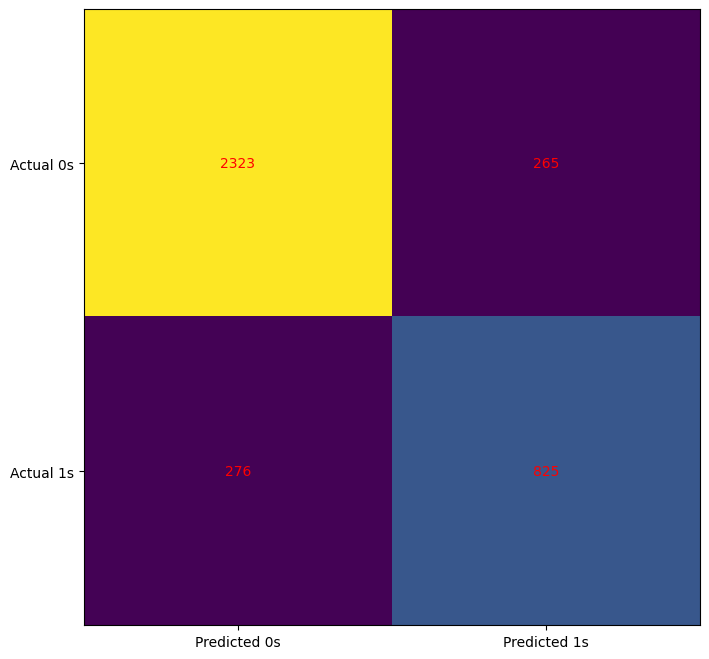

```
test data
              precision    recall  f1-score   support

           0       0.90      0.89      0.89       647
           1       0.74      0.76      0.75       276

    accuracy                           0.85       923
   macro avg       0.82      0.82      0.82       923
weighted avg       0.85      0.85      0.85       923
```

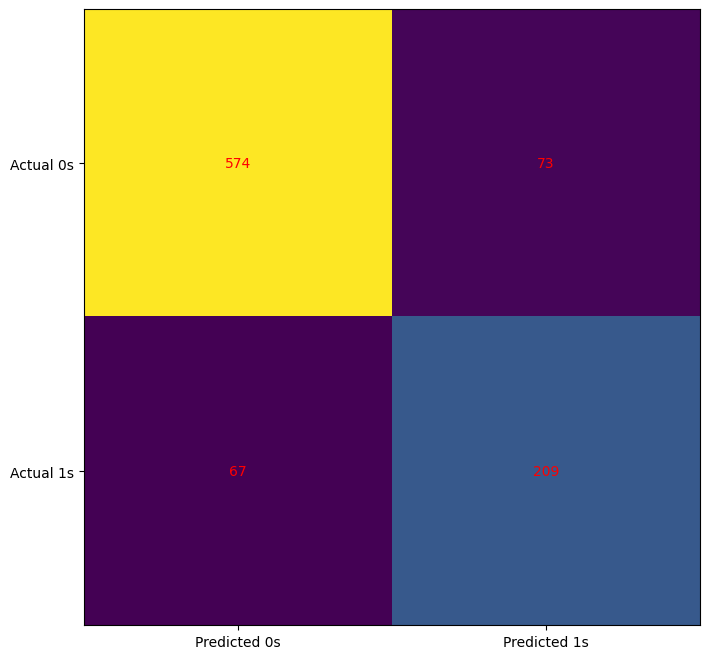

```python
#select the training data
name, X_, y_ = get_X_y[0]

#buil a decision tree model
DT_classifier = DecisionTreeClassifier(max_depth=4, random_state= 42)

#fit the model
DT_classifier.fit(X_, y_['status'])

#Loop through the training and testing data and make predictions
for name, X_, y_ in get_X_y:
  value_proba = DT_classifier.predict_proba(X_)
  #convert all possible negative values to zero
  value_proba[value_proba < 0] = 0
  #append the probabilities to the dataset
  y_['status_pred_proba'] = value_proba[:,1]

  #get actual status predictions with a 0.5 threshold
  y_['status_pred'] = y_['status_pred_proba'] > 0.5

#get the scores
  score = metric_score(y_true = y_['status'], y_pred= y_['status_pred'])
```

Commments:

- Our model is doing a great job in terms of not overfitting. It is important to mention that in this case, we are more interested in f1-score, the balance between precision and recall. We want to reduce false positives. We want to know which customers are not potential paying customers but our model predicted that they are. We do not want to waste our money targeting leads that will not convert into paying customers.Similarly, we want to reduce the false negative, the leads that are more likely to convert into paying customers but our model is predicting that they are not going to convert. This can lead to lost revenue.
- In short, we do not want to focus on leads that will never convert into paying customers and waste our money, but at the same time we do not want to miss leads that are more likely to convert which can lead to a loss in revenue.Hence, we will work on improving our F1-score. However,the above model is fantastic.

Let us improve it anyways.

```python
#get print the ROC score
for name, X_, y_ in get_X_y:
  score_ROC = metric_for_status(y_true=y_['status'], y_score=y_['status_pred_proba'])
```

```
train     : 0.921
test      : 0.913
```

The difference between the ROC_AUC scores for the training and testing datasets is not huge. This further confirms that our model is not overfitting.

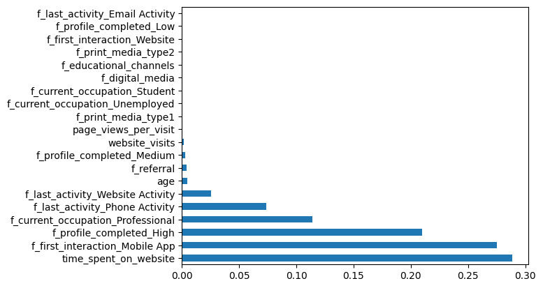

```python
#get the feature importance
DT_feature_imp = (pd.Series(DT_classifier.feature_importances_, index =X_train.columns.tolist()).sort_values(ascending = False).round(4) )
#plot them
DT_feature_imp.plot( kind ='barh')
```

- The feature importance plot shows us that time_spent_on_website is the most important metric that determines whether a lead will convert into a paying customer our not. Following my first interaction by Mobile App, profile_completion_high, current_ocupation_proffessional, last_activity_phone Activity, last activity_website Activity, age, referral, profile_completion_medium,and website_visits. Other features, seem to be insignificant, meaning that they do have no influence in converting leads into paying customers.
- Therefore, the business should focus only on those 10 features/metrics.
- It is important to the leads customers to complete their profile through constant reminder since this increases the chances of converting them into paying customers.
- We should focus on people with Jobs and who spend a lot of time on our website.

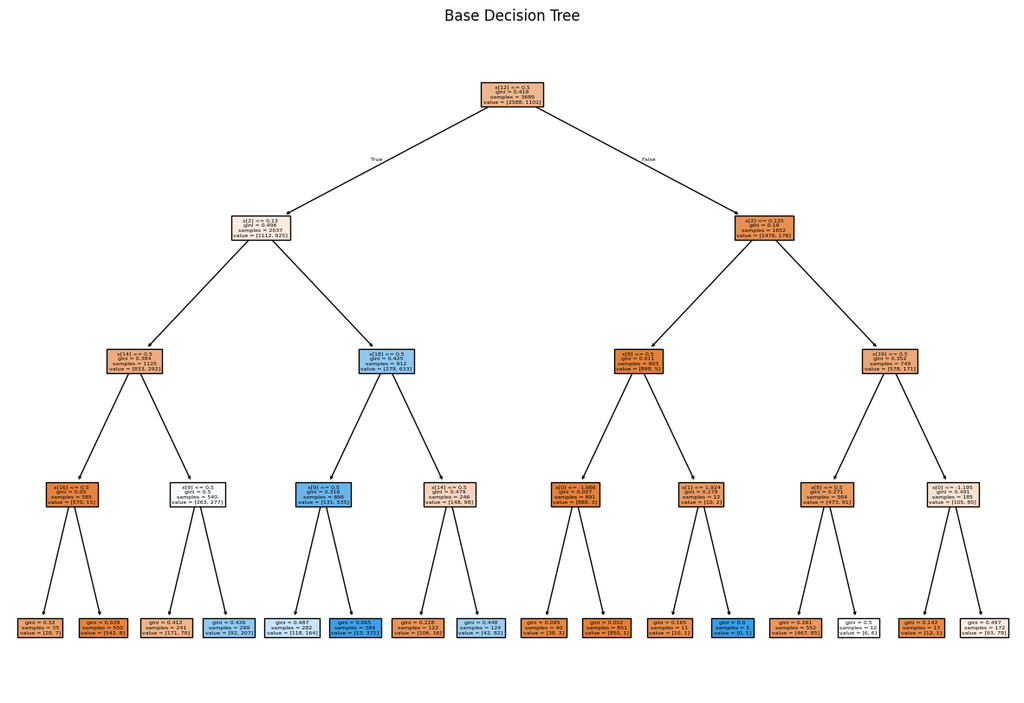

```python
#plot the tree
plt.figure(figsize=(15, 10))
plot_tree(DT_classifier, filled=True)
plt.title("Base Decision Tree")
plt.show()
```

## Do we need to prune the tree?

Accodring to the feature importance, there are many features that are irrelevant for our analysis. Hence, it would be great to remove those features to see if we can get better predictions. However, in terms of overfitting, our model is doing a great job, hence we do not need to prune it to solve for overfitting, but it is woth trying anything that could potencially improve our model.

```python
#using the gridsearch for hyperparameter tunning

#create a grid of hyperparamenters
param_grid = {'criterion': ['gini', 'entropy'],
              'max_depth': [2,4,6,8,10],
              'min_samples_split' :[2,4,6,8,10],
              'min_samples_leaf': [2,4,6,8,10],
              'ccp_alpha': [0.0, 0.001, 0.01, 0.1] #this parameter is used for minimal cost-complexity proning addressing the question above
}

#declare the estimator
DT_clf_grid = DecisionTreeClassifier(random_state = 42)
#define the gridsearch model
grid_search = GridSearchCV(DT_clf_grid, param_grid , cv = 5)
#fit the gridsearch model
grid_search.fit(X_,y_['status'])

#print the best hyperparameter combination
print('the best hyperparameters are:', grid_search.best_params_)
```

```
the best hyperparameters are: {'ccp_alpha': 0.001, 'criterion': 'gini', 'max_depth': 6, 'min_samples_leaf': 2, 'min_samples_split': 2}
```

```
train data
              precision    recall  f1-score   support

           0       0.89      0.86      0.88      2588
           1       0.70      0.76      0.73      1101

    accuracy                           0.83      3689
   macro avg       0.80      0.81      0.80      3689
weighted avg       0.84      0.83      0.83      3689
```

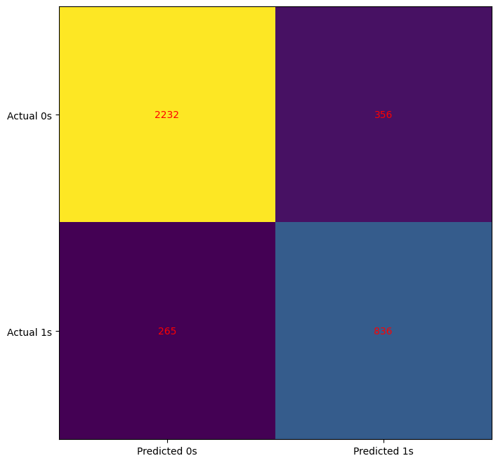

```
test data
              precision    recall  f1-score   support

           0       0.90      0.88      0.89       647
           1       0.74      0.78      0.75       276

    accuracy                           0.85       923
   macro avg       0.82      0.83      0.82       923
weighted avg       0.85      0.85      0.85       923
```

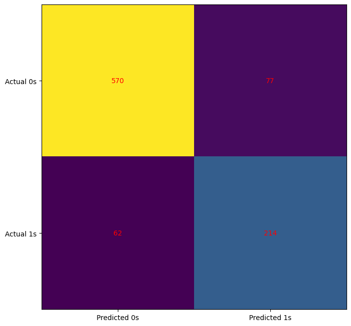

```python
#fit a model with the best hyperparameters

DT_best_clf = DecisionTreeClassifier(criterion = 'gini',
                                     max_depth = 6,
                                     min_samples_leaf = 2,
                                     min_samples_split =2,
                                     max_features = 'sqrt',
                                     random_state = 42,
                                     ccp_alpha = 0.001)
DT_best_clf.fit(X_, y_['status'])

#loop through the training and testing data and get predictions
for name, X_, y_ in get_X_y:
  value_best = DT_best_clf.predict_proba(X_)
  #conver prossible negative prob values to zero
  value_best[value_best<0] = 0
  #add the prob to the data
  y_['status_prob_best'] = value_best[:,1]

  #get binary status predictions with a 0.5 threshold
  y_['status_pred_best'] = y_['status_prob_best'] > 0.5

  #get the scores
  score = metric_score(y_true = y_['status'], y_pred= y_['status_pred_best'])
```

```python
# get the AUR_ROC score
for name, X_, y_ in get_X_y:
  score_ROC = metric_for_status(y_true = y_['status'], y_score= y_['status_prob_best'])
```

```
train     : 0.885
test      : 0.916
```

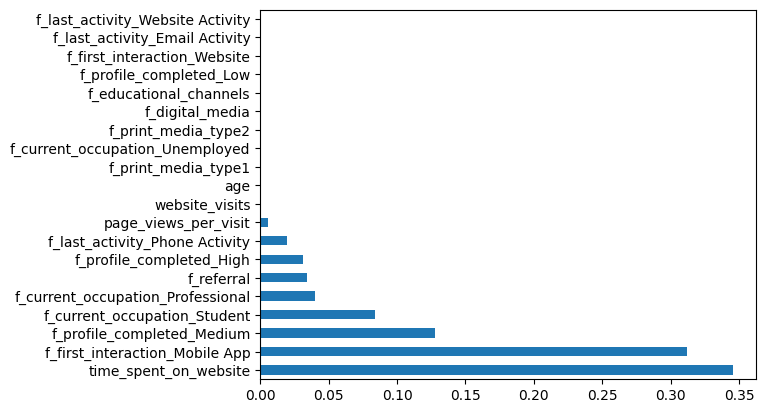

```python
#feature importance
importance_best = pd.Series(DT_best_clf.feature_importances_, index = X_train.columns.tolist()).sort_values(ascending= False)
importance_best.plot(kind ='barh')
```

Unlike the base model, this model regards age and website_visits variables as irrelevant, and includes page_views_per_visit as a feature with some importance.

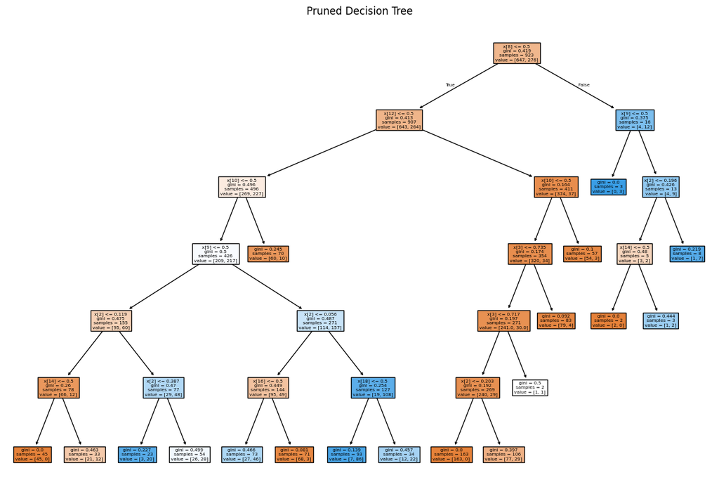

```python
#plot the tree
plt.figure(figsize=(15, 10))
plot_tree(DT_best_clf, filled=True)
plt.title("Pruned Decision Tree")
plt.show()
```

So far we have been using a threshold of 0.5. Let's draw a graph of precision vs recall to find the soft spot for our threshold to see if that would improve our model.

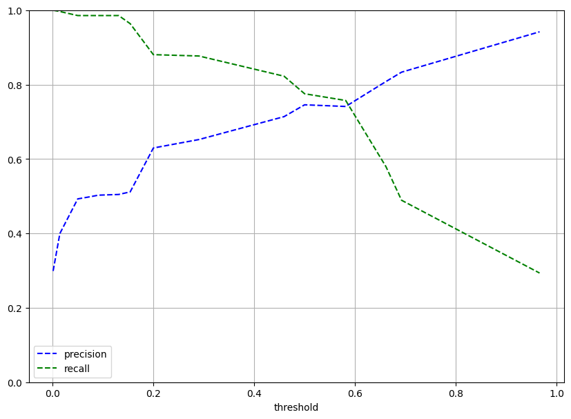

```python
#get the precision recall curve usig our base DT model
precision, recall, threshold = precision_recall_curve(y_true= y_['status'] , y_score =y_['status_pred_proba'])


#plot the curve
plt.figure(figsize = (10,7))
plt.plot(threshold, precision[:-1], 'b--', label ='precision')
plt.plot(threshold, recall[:-1], 'g--', label = 'recall')
plt.xlabel('threshold')
plt.grid(visible= True)
plt.legend()
plt.ylim([0,1])
plt.show()
```

The softspot for the threshold where the precision and recall balance is 0.581. Let us see if this threshold can improve the F1-score.

```
train data
              precision    recall  f1-score   support

           0       0.89      0.90      0.90      2588
           1       0.76      0.75      0.75      1101

    accuracy                           0.85      3689
   macro avg       0.83      0.82      0.82      3689
weighted avg       0.85      0.85      0.85      3689
```

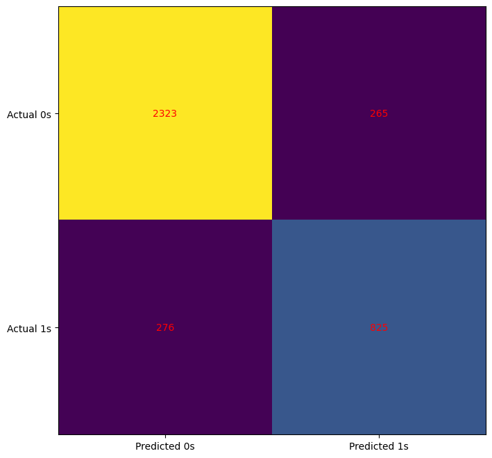

```
test data
              precision    recall  f1-score   support

           0       0.90      0.89      0.89       647
           1       0.74      0.76      0.75       276

    accuracy                           0.85       923
   macro avg       0.82      0.82      0.82       923
weighted avg       0.85      0.85      0.85       923
```

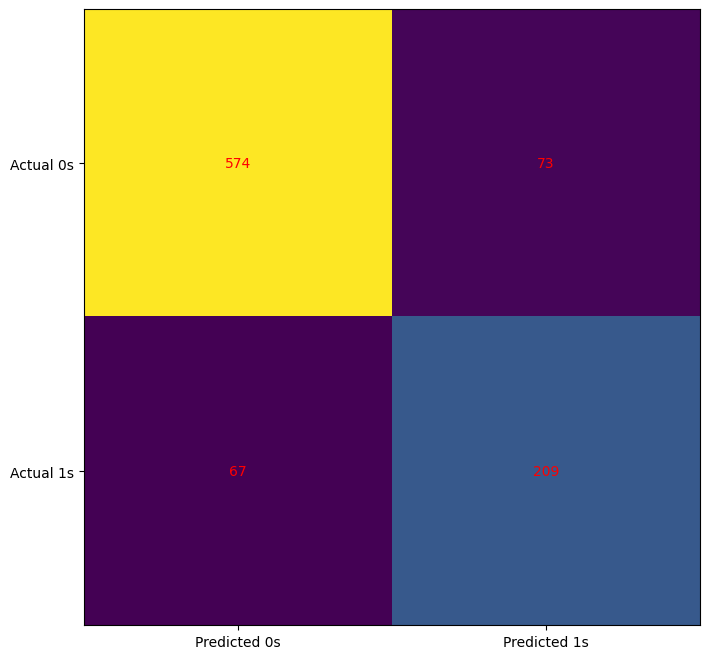

```python
#select the training data
name, X_, y_ = get_X_y[0]

#buil a decision tree model
DT_clf_th = DecisionTreeClassifier(max_depth=4, random_state= 42)

#fit the model
DT_clf_th.fit(X_, y_['status'])

#transform the data and make predictions
for name, X_, y_ in get_X_y:
  value_proba_ = DT_clf_th.predict_proba(X_)
  #convert all possible negative values to zero
  value_proba_[value_proba_ < 0] = 0
  #append the probabilities to the dataset
  y_['status_pred_proba_'] = value_proba_[:,1]

  #get actual status predictions with a 0.5 threshold
  y_['status_pred_'] = y_['status_pred_proba_'] >=  0.581

#get the scores
  score = metric_score(y_true = y_['status'], y_pred= y_['status_pred_'])
```

Our F1- score did not improve with the change in the threshold.

Let us try and run a model with the most important features only.

```python
most_imp_features_base = DT_feature_imp[DT_feature_imp > 0.004]
most_imp_features_base
```

|  | 0 |
| --- | --- |
| time_spent_on_website | 0.2883 |
| f_first_interaction_Mobile App | 0.2752 |
| f_profile_completed_High | 0.2097 |
| f_current_occupation_Professional | 0.1139 |
| f_last_activity_Phone Activity | 0.0736 |
| f_last_activity_Website Activity | 0.0256 |
| age | 0.0046 |
| f_referral | 0.0043 |

**dtype:** float64

```python
#the most important features according to the pruned model
most_imp_features = importance_best[importance_best > 0.005]
most_imp_features
```

|  | 0 |
| --- | --- |
| time_spent_on_website | 0.345283 |
| f_first_interaction_Mobile App | 0.312240 |
| f_profile_completed_Medium | 0.127860 |
| f_current_occupation_Student | 0.083972 |
| f_current_occupation_Professional | 0.039827 |
| f_referral | 0.034037 |
| f_profile_completed_High | 0.031358 |
| f_last_activity_Phone Activity | 0.019731 |
| page_views_per_visit | 0.005691 |

**dtype:** float64

```
train data
              precision    recall  f1-score   support

           0       0.88      0.90      0.89      2588
           1       0.76      0.71      0.73      1101

    accuracy                           0.85      3689
   macro avg       0.82      0.81      0.81      3689
weighted avg       0.84      0.85      0.84      3689
```

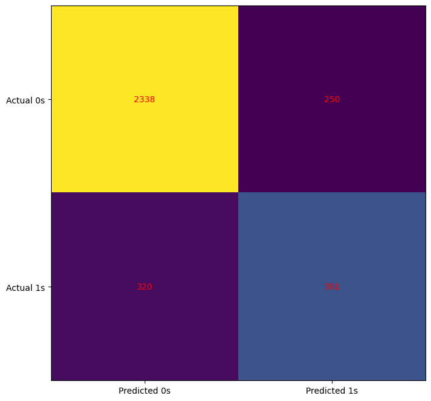

```
test data
              precision    recall  f1-score   support

           0       0.89      0.91      0.90       647
           1       0.78      0.73      0.76       276

    accuracy                           0.86       923
   macro avg       0.84      0.82      0.83       923
weighted avg       0.86      0.86      0.86       923
```

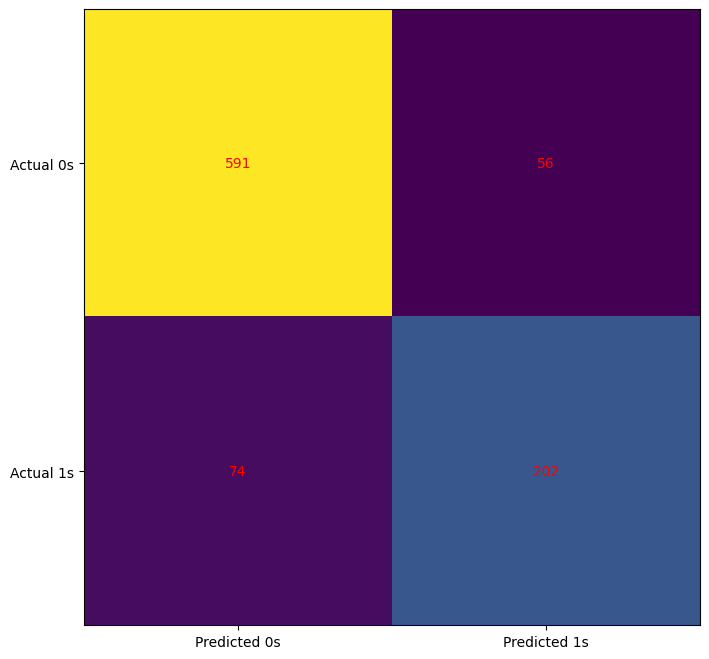

```python
#buil a decision tree model
DT_clf_imp = DecisionTreeClassifier(max_depth=4, random_state= 42)

#fit the model
DT_clf_imp.fit(X_[most_imp_features_base.index.tolist()], y_['status'])

#transform the data and make predictions
for name, X_, y_ in get_X_y:
  value_proba_imp = DT_clf_imp.predict_proba(X_[most_imp_features_base.index.tolist()])
  #convert all possible negative values to zero
  value_proba_imp[value_proba_imp < 0] = 0
  #append the probabilities to the dataset
  y_['status_pred_proba_imp'] = value_proba_imp[:,1]

  #get actual status predictions with a 0.5 threshold
  y_['status_pred_imp'] = y_['status_pred_proba_imp'] > 0.5

#get the scores
  score = metric_score(y_true = y_['status'], y_pred= y_['status_pred_imp'])
```

```python
# get the AUR_ROC score
for name, X_, y_ in get_X_y:
  score_ROC = metric_for_status(y_true = y_['status'], y_score= y_['status_pred_proba_imp'])
```

```
train     : 0.91
test      : 0.921
```

Note: We ran the pruned model with its most important features but the score did not improve. Hence I am not going to include it here, becasue the notebook is getting too lengthy.

## Building a Random Forest model

```
train data
              precision    recall  f1-score   support

           0       0.86      0.94      0.90      2588
           1       0.83      0.63      0.71      1101

    accuracy                           0.85      3689
   macro avg       0.84      0.79      0.81      3689
weighted avg       0.85      0.85      0.84      3689
```

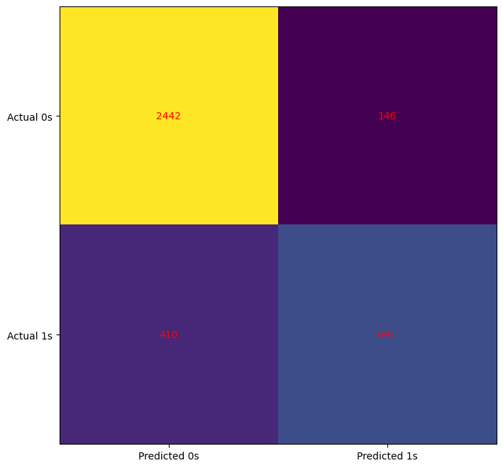

```
test data
              precision    recall  f1-score   support

           0       0.87      0.94      0.90       647
           1       0.83      0.67      0.74       276

    accuracy                           0.86       923
   macro avg       0.85      0.80      0.82       923
weighted avg       0.86      0.86      0.85       923
```

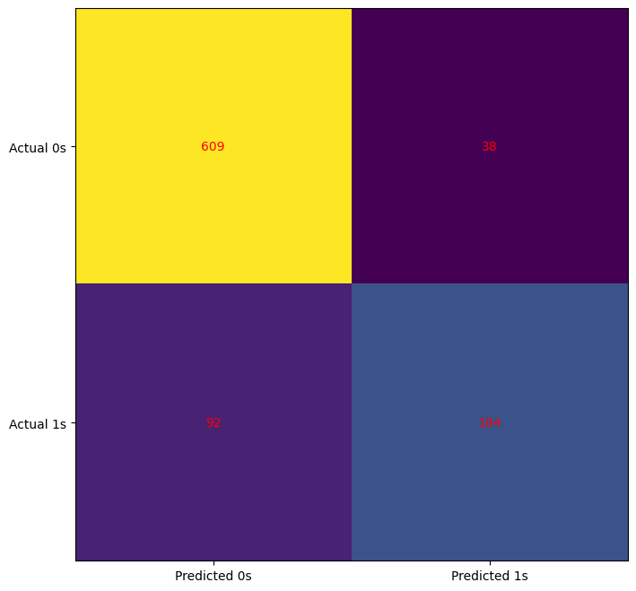

```python
#build a random forest tree base model
RF_clf = RandomForestClassifier(random_state= 42, max_depth= 4)

#fit the model
RF_clf.fit(X_, y_['status'])

#loop through the train and test data to get predictions and scores
for name, X_, y_ in get_X_y:
  value_RF = RF_clf.predict_proba(X_)
  #covert possible negative values to zero
  value_RF[value_RF <0] =0
  #add the probabilities to the dataset
  y_['status_proba_RF'] = value_RF[:,1]

  #get the actual predictions
  y_['status_pred_RF'] =  y_['status_proba_RF'] > 0.5

  #get the scores
  score = metric_score(y_true= y_['status'], y_pred= y_['status_pred_RF'])
```

```python
#get the AUR_ROC score
for name, X_, y_ in get_X_y:
  score_ROC = metric_for_status(y_true=y_['status'], y_score=y_['status_proba_RF'])
```

```
train     : 0.909
test      : 0.934
```

The random forest model yields amazing results, but not enough to improve the the F1 score further than the previous models. However, there is still much room for improvement in this model.